# Machine Learning of Self Movement

Author: edettman

### Executive Summary

In this exercise, data from personal movement measurement devices was analyzed to develop a predictive model of the manner in which the individual performed. A random forest model was fitted to a training set with 5-fold cross validation using approximately 50 variables.

### Overview

Participants lifted dumbells while wearing the movement tracking device.

#### Class variables

- exactly according to the specification (Class A)
- throwing the elbows to the front (Class B)
- lifting the dumbbell only halfway (Class C)
- lowering the dumbbell only halfway (Class D)
- throwing the hips to the front (Class E)

To find a model, I loaded the training data-set into R and removed the variables associated with the timestamps, then fixed some of the columns that were changed to factors due to a ‘DIV/0’ value in some of those. Then, I removed the columns with greater than 95% NA values, as the not-NA values did not seem to be associated with any particular class.

#### Load Data

```r
library(caret)
library(ggplot2)
library(doParallel)
library(knitr)


registerDoParallel(cores = 4)


setwd('C:/practical machine learning')
exercise <- read.csv('pml-training.csv')

#cut out the timestamps
exercise <- exercise[,c(2,7:160)]

# Coerce some of the variables to numeric
for(i in 1:155){
      if('#DIV/0!' %in% exercise[,i]){
            exercise[,i] <- as.numeric(as.character(exercise[,i]))
}}




# many of the columns are mostly NA, see if any class is more associated with the NA values
tapply(rowSums(is.na(exercise)), exercise$classe, mean)
```

```
##        A        B        C        D        E
## 98.22473 98.08902 98.12887 98.03483 98.00028
```

```r
# remove those variables with > 95% NA as they are spread across all classes
idx <- which(apply(exercise, 2, function(x) {
      mean(is.na(x))
} ) > 0.95)

exercise <- exercise[,-idx]
```

#### Many of the variables are bimodal, not associated with a specific class

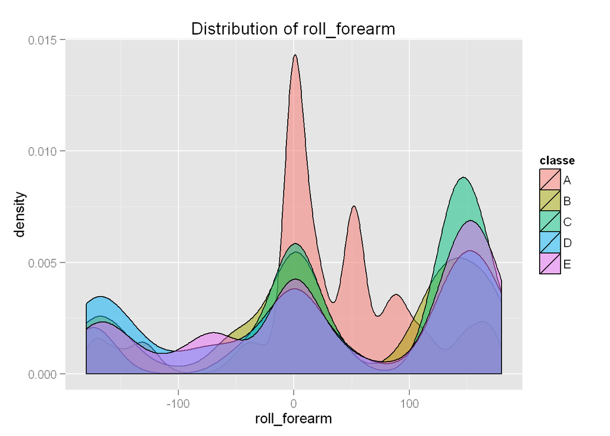

```r
qplot(x = roll_forearm, data = exercise, fill = classe, alpha = I(0.5), geom = 'density') + ggtitle('Distribution of roll_forearm')
```

This makes a gaussian model based prediction method difficult to fit. Decision trees do not make assumptions about the distributions, so a random forest model should not be too affected by this non-gaussian data.

### Fit a Random Forest Model with 5 fold cross validation

All of the variables in the dataset were fit against the classe variable in a sub-training set containing 50% of the data. To cross-validate the model, I used the ‘cv’ switch with the trainControl() function from the caret package with a total of 5 folds. It’s very important to use mutliple cores for this operation, as it is very slow.

```r
#create subsets of the exercise data set
set.seed(1)
inTrain <- createDataPartition(y = exercise$classe,
                               p = 0.5, list = F)

training <- exercise[inTrain, ]
testing <- exercise[-inTrain,]


modRF <- train(classe ~ ., data = training, method="rf",
                prox = T, importance = T, allowParallel = T,
                trControl = trainControl(method = "cv", number=5))
```

#### Confusion Matrix of Random Forest Model

```r
confusionMatrix(predict(modRF, training), training$classe)
```

```
## Confusion Matrix and Statistics
##
##           Reference
## Prediction    A    B    C    D    E
##          A 2790    0    0    0    0
##          B    0 1899    0    0    0
##          C    0    0 1711    0    0
##          D    0    0    0 1608    0
##          E    0    0    0    0 1804
##
## Overall Statistics
##
##                Accuracy : 1
##                  95% CI : (0.9996, 1)
##     No Information Rate : 0.2843
##     P-Value [Acc > NIR] : < 2.2e-16
##
##                   Kappa : 1
##  Mcnemar's Test P-Value : NA
##
## Statistics by Class:
##
##                      Class: A Class: B Class: C Class: D Class: E
## Sensitivity            1.0000   1.0000   1.0000   1.0000   1.0000
## Specificity            1.0000   1.0000   1.0000   1.0000   1.0000
## Pos Pred Value         1.0000   1.0000   1.0000   1.0000   1.0000
## Neg Pred Value         1.0000   1.0000   1.0000   1.0000   1.0000
## Prevalence             0.2843   0.1935   0.1744   0.1639   0.1839
## Detection Rate         0.2843   0.1935   0.1744   0.1639   0.1839
## Detection Prevalence   0.2843   0.1935   0.1744   0.1639   0.1839
## Balanced Accuracy      1.0000   1.0000   1.0000   1.0000   1.0000
```

In this model there are 500 trees and each would be very difficult to interpret. With importance = T and the importance function, we can see how much the model suffers if the variable is permuted. We see the top 10 in this measure of importance.

```r
imp <- importance(modRF$finalModel, type = 1)

kable(head(data.frame(decAccuracy = imp[order(imp, decreasing = T),]), n = 10), digits = 2)
```

|  | decAccuracy |
| --- | --- |
| roll_belt | 80.98 |
| num_window | 80.94 |
| pitch_forearm | 74.57 |
| yaw_belt | 67.81 |
| magnet_dumbbell_z | 57.31 |
| magnet_dumbbell_y | 52.26 |
| pitch_belt | 45.78 |
| gyros_dumbbell_y | 38.47 |
| accel_dumbbell_y | 36.18 |
| accel_forearm_x | 30.86 |

### Estimated out of sample error

To estimate the out of sample error, cross validation with 5 folds was used, then the model was tested against the 50% of data that was reserved for the test set. The overall accuracy was very good, and further details are summaried in the below confusion matrix.

#### Out of bag error estimate With cross validation

```r
modRF$finalModel
```

```
##
## Call:
##  randomForest(x = x, y = y, mtry = param$mtry, importance = ..2,      proximity = ..1, allowParallel = ..3)
##                Type of random forest: classification
##                      Number of trees: 500
## No. of variables tried at each split: 30
##
##         OOB estimate of  error rate: 0.34%
## Confusion matrix:
##      A    B    C    D    E  class.error
## A 2788    1    0    0    1 0.0007168459
## B    7 1889    2    1    0 0.0052659294
## C    0    4 1707    0    0 0.0023378141
## D    0    0   10 1598    0 0.0062189055
## E    0    1    0    6 1797 0.0038802661
```

#### Error in the earlier separated test set

```r
confusionMatrix(predict(modRF, testing), testing$classe)
```

```
## Confusion Matrix and Statistics
##
##           Reference
## Prediction    A    B    C    D    E
##          A 2788    3    0    0    0
##          B    2 1890    2    0    2
##          C    0    3 1709   11    0
##          D    0    2    0 1596   13
##          E    0    0    0    1 1788
##
## Overall Statistics
##
##                Accuracy : 0.996
##                  95% CI : (0.9946, 0.9972)
##     No Information Rate : 0.2844
##     P-Value [Acc > NIR] : < 2.2e-16
##
##                   Kappa : 0.995
##  Mcnemar's Test P-Value : NA
##
## Statistics by Class:
##
##                      Class: A Class: B Class: C Class: D Class: E
## Sensitivity            0.9993   0.9958   0.9988   0.9925   0.9917
## Specificity            0.9996   0.9992   0.9983   0.9982   0.9999
## Pos Pred Value         0.9989   0.9968   0.9919   0.9907   0.9994
## Neg Pred Value         0.9997   0.9990   0.9998   0.9985   0.9981
## Prevalence             0.2844   0.1935   0.1744   0.1639   0.1838
## Detection Rate         0.2842   0.1927   0.1742   0.1627   0.1823
## Detection Prevalence   0.2845   0.1933   0.1756   0.1642   0.1824
## Balanced Accuracy      0.9994   0.9975   0.9986   0.9954   0.9958
```

The accuracy is very good in the cross-validated error estimate and using the separated test set.

I made the choices of random forest with 5 fold cross validation because this model performed the best in the training set and the estimate of out of sample error was very good. Not shown here, but I tried linear discriminant analysis and trees prior to this model, but neither worked very well. The linear discriminant analysis may have been affected by the non-gaussian data variables in the data-set. The biggest downside of the model identified here is that is very slow and took a long time to fit.

#### Estimate values from the provided test set (Submission Portion)

```r
testing2 <- read.csv('pml-testing.csv')

testing2 <- testing2[,c(2,7:160)]


for(i in 1:155){
      if('#DIV/0!' %in% testing2[,i]){
            testing2[,i] <- as.numeric(as.character(testing2[,i]))
      }
}

testing2 <- testing2[, -idx]

answers <- predict(modRF, testing2)
answers
```

```
##  [1] B A B A A E D B A A B C B A E E A B B B
## Levels: A B C D E
```